# Derive data

Deriving clean dataset `dsL` from NLSY97 extract.  
[back to Appendix](http://statcanvas.net/thesis/appendix/)

# Preparing the dataset

## Data Retrieval

Using [NLS Investigator](https://www.nlsinfo.org/investigator/pages/login.jsp) a list of variables was downloaded from [NLS](http://www.bls.gov/nls/) datasets. All the downloaded materials were unzipped into the folder /Data/Extracts/NLSY97_Religiosity_20042014, located in the GitHub Repository. (The naming convention is “Study_Focus_DDMMYYYofDownload”)

#### The downloaded zip.forlder included:

NLSY97_Religiosity_20042014.cdb - **codebook** containing item descriptions  
NLSY97_Religiosity_20042014.csv - **data** in comma delimited format  
NLSY97_Religiosity_20042014.NLSY97 - **tagset**, the list of variables in the downloaded dataset  
NLSY97_Religiosity_20042014.dtc - STATA **dictionary** file of selected variables, contains data as well

We import the raw data of NLSY97 from .**csv** file and make initial clean up.

The STATA **dictionary** file printed below lists the selected variables : unique NLSY97 reference numbers (RNUM) are paired wtih their descriptive labels (VARIABLE TITLE).

## Selected variables

```
        RNUM                                VARIABLE_TITLE
1   R0323900              # DAYS/WK TYP FAM RELIGIOUS 1997
2   R2165200              # DAYS/WK TYP FAM RELIGIOUS 1998
3   R3483100              # DAYS/WK TYP FAM RELIGIOUS 1999
4   R4881300              # DAYS/WK TYP FAM RELIGIOUS 2000
5   S2977900 CURRENTLY HAVE ACCESS TO INTERNET? (SAQ) 2003
6   S4676700 CURRENTLY HAVE ACCESS TO INTERNET? (SAQ) 2004
7   S6308900 CURRENTLY HAVE ACCESS TO INTERNET? (SAQ) 2005
8   S8329800 CURRENTLY HAVE ACCESS TO INTERNET? (SAQ) 2006
9   T0737600 CURRENTLY HAVE ACCESS TO INTERNET? (SAQ) 2007
10  T2779700 CURRENTLY HAVE ACCESS TO INTERNET? (SAQ) 2008
11  T4494400 CURRENTLY HAVE ACCESS TO INTERNET? (SAQ) 2009
12  T6141400 CURRENTLY HAVE ACCESS TO INTERNET? (SAQ) 2010
13  T7635300 CURRENTLY HAVE ACCESS TO INTERNET? (SAQ) 2011
14  R1193900                  CV_AGE(MONTHS)_INT_DATE 1997
```

[output cut: 119 more lines]

After renaming the variables, we arrange data in wide format (variable/occasions as columns), arriving at the basis dataset `dsSource`, which contains

```r
ncol(dsSource)
```

```
[1] 133
```

variables and

```r
nrow(dsSource)
```

```
[1] 8984
```

respondents.

Dictionary file is imported into Excel file “ItemMapping_20042014.xlsx”, where variables are renamed and organized with respect to occasssions of their measurement. Renaming and additional data grooming is done by `@knitr TweakData` chunk in the sourced .R file. The result is variable-by-occasion databox slice.

## Databox

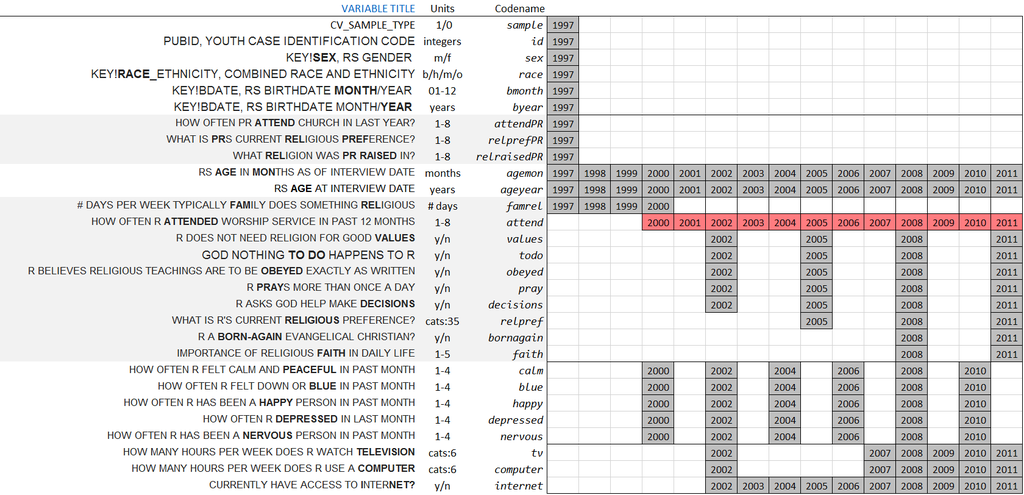

[Interactive version](http://statcanvas.net/thesis/databox/)

Variables on vertical dimension and occasions on horizontal intersect over grey-filled boxes displaying the year of the wave for which data are available. Variable **attend** is marked by red to indicate that it is the primary quantification of religiosity in the statistical models used in this study.

The variable dimension of the databox slice is represented by three identifiers adjacent to the left of the grid.

- **Variable Title** - verbatim identifier from NLSY97
- **Unit** - describes the scales used to measure variables
- **Codename** - the (new) name of the variable, as it is used in R code

## Selected variables

The light grey background highlights the variables related to religion and spirituality. The first section of items (**attendPR**, **relprefPR**, **relraisedPR**) gives data on the religiosity of [parents](http://www.bls.gov/nls/quex/r1/y97rd1pquex.htm) of the respondents, whose households were sampled into NLSY97. Another grey section lists the items related to the religiosity of the youth, which give data on their religious behaviors (**relpref**, **attend**, **pray**, **decisions**) and attitudes (**values**, **todo**, **obeyed**, **bornagain**, **faith**).

Context variables and covariates are on white background. The top section gives basic demographics: the month (**bmonth**) and year (**byear**) of birth, sex (**sex**), race (**race**), as well as the indicator whether the individual is a member of the cross-sectional sampling or a special oversample of minorities (**sample**). Two age variables are located between the religiosity sections: age at the time of the interview in months (**agemon**) and years (**ageyear**). At the bottom are self-reports on emotional wellbeing (**calm**, **blue**, **happy**, **depressed**, **nervous**) and media activities (**internet**, **computer**, **tv**) of respondents.

To review original questionnaire cards of NLSY97 as well as descriptive statistics for the selected variables see the [Interactive version](http://statcanvas.net/thesis/databox/)

## dsL - initial dataset

This databox slice corresponds to the dataset `dsL`

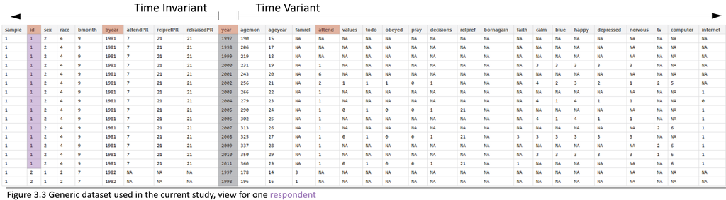

which transposes the former, distributing variables on the horizontal axis. Variable **year** keeps track of measurement round and separated two kinds of variables: those, which values do not change with time and those that were measured at multiple occasions. This distinction will be of convenience in later discussion of statistical models. The dataset in figure 3.3 is referred to as `dsL` throughout this work and the accompanying R code . It defines the scope of NLSY97 data used in the current study and has a direct correspondence to the databox slice from figure 3.2. While other variables of interest might be added in course or reproduction of this research, it is useful to think of such dataset as a midway point between raw data and model-specific datasets

## Factor labels

Section **Labeling Factors** in the [Metrics](https://github.com/andkov/Longitudinal_Models_of_Religiosity_NLSY97/blob/master/Models/Descriptives/Metrics.md) report explains how script [LabelingFactorLevels](https://github.com/andkov/Longitudinal_Models_of_Religiosity_NLSY97/blob/master/Scripts/Data/LabelingFactorLevels.R) sourced in here augements the dataset `dsL` with a copy of initial variables, labeled and saved as factors.

```r
source(file.path(pathDir,"Scripts/Data/LabelingFactorLevels.R"))
```

By adding or removing an “F” to the end of the variable, one can select the variable either in the raw metric (**attend**) or as a labeled factor (**attendF**):

```r
ds<- dsL[dsL$id==1,c("id","year","attend","attendF")]
str(ds)
```

```
'data.frame':   15 obs. of  4 variables:
 $ id     : int  1 1 1 1 1 1 1 1 1 1 ...
 $ year   : int  1997 1998 1999 2000 2001 2002 2003 2004 2005 2006 ...
 $ attend : num  NA NA NA 1 6 2 1 1 1 1 ...
 $ attendF: Ord.factor w/ 8 levels "Never"<"Once or Twice"<..: NA NA NA 1 6 2 1 1 1 1 ...
```

```r
print(ds)
```

```
   id year attend         attendF
1   1 1997     NA            <NA>
2   1 1998     NA            <NA>
3   1 1999     NA            <NA>
4   1 2000      1           Never
5   1 2001      6 About once/week
6   1 2002      2   Once or Twice
7   1 2003      1           Never
8   1 2004      1           Never
9   1 2005      1           Never
10  1 2006      1           Never
11  1 2007      1           Never
12  1 2008      1           Never
13  1 2009      1           Never
14  1 2010      1           Never
15  1 2011      1           Never
```

## Saving clean dataset

Finally, we output the created clean dataset `dsL` as a .cvs file. Also, it is saved in an .rds format, native to R, which preserves factor levels, not saved in .csv. This report is computationally intensive, so it is typically omitted from the reproduction cycle. Instead, from now on, the initial point of departure for data projects will be the import of **dsL.rds** file produced by this report.

```r
pathdsLcvs <- file.path(getwd(),"Data/Derived/dsL.csv")
write.csv(dsL,pathdsLcvs,  row.names=FALSE)

pathdsLrds <- file.path(pathDir,"Data/Derived/dsL.rds")
saveRDS(object=dsL, file=pathdsLrds, compress="xz")
```

## Working with NLS Investigator

To explore the variables in the native context of NLS, go to [NLS Investigator](https://www.nlsinfo.org/investigator/pages/login.jsp) (you will have to register a free account to keep track of your progress), select “NLYS97 1997-2011” in the first dropdown box and then click “Choose File” under “Upload Tagset.” Select the file **NLSY97_Religiosity_20042014.NLSY97** from the folder **/Data/Extract/NLSY97_Religiosity_20042014**. All the variables from this extract will be loaded into NLS Web Investigator.

Alternatively, one can locate the particular item of interest by copying and pasting its “Variable Title” it into “Word in Title” search line of the [NLS Investigator](https://www.nlsinfo.org/investigator/pages/login.jsp), as indicated in the graphic below.

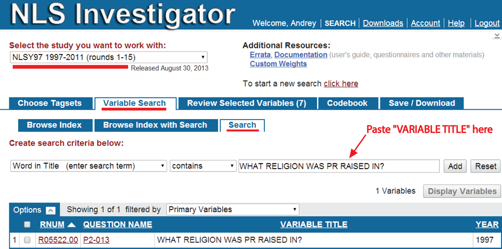

# Read more

Reports in `./Models/Descriptives`:

- [Metrics](https://github.com/andkov/Longitudinal_Models_of_Religiosity_NLSY97/blob/master/Models/Descriptives/Metrics.md) - how values of items are labeled (**Continue**)
- [Descriptives](https://github.com/andkov/Longitudinal_Models_of_Religiosity_NLSY97/blob/master/Models/Descriptives/Descriptives.md) - basic stats of various items
- [Attendance](https://github.com/andkov/Longitudinal_Models_of_Religiosity_NLSY97/blob/master/Models/Descriptives/Attendance.md) - focus on church attendence over time
- [Databox](https://github.com/andkov/Longitudinal_Models_of_Religiosity_NLSY97/blob/master/Models/Descriptives/Databox.Rmd)

See also

- [Deriving Data from NLYS97 extract](https://github.com/andkov/Longitudinal_Models_of_Religiosity_NLSY97/blob/master/Data/Derive_dsL_from_Extract.md)
- [Data Manipulation Guide](https://github.com/andkov/Longitudinal_Models_of_Religiosity_NLSY97/blob/master/Vignettes/dplyr/Data_Manipulation_Guide.md)